# A Method for Deriving Information from Running R Code

It is often useful to tap information from a running R script. Obvious use cases include monitoring the consumption of resources (time, memory) and logging. Perhaps less obvious cases include tracking changes in R objects or collecting the output of unit tests. In this paper, we demonstrate an approach that abstracts the collection and processing of such secondary information from the running R script. Our approach is based on a combination of three elements. The first element is to build a customized way to evaluate code. The second is labeled *local masking* and it involves temporarily masking a user-facing function so an alternative version of it is called. The third element we label *local side effect*. This refers to the fact that the masking function exports information to the secondary information flow without altering a global state. The result is a method for building systems in pure R that lets users create and control secondary flows of information with minimal impact on their workflow and no global side effects.

Mark P.J. van der Loo (Statistics Netherlands)  
2021-07-13

## 1 Introduction

The R language provides a convenient language to read, manipulate, and write data in the form of scripts. As with any other scripted language, an R script gives a description of data manipulation activities, one after the other, when read from top to bottom. Alternatively, we can think of an R script as a one-dimensional visualization of data flowing from one processing step to the next, where intermediate variables or pipe operators carry data from one treatment to the next.

We run into limitations of this one-dimensional view when we want to produce data flows that are somehow ‘orthogonal’ to the flow of the data being treated. For example, we may wish to follow the state of a variable while a script is being executed, report on progress (logging), or keep track of resource consumption. Indeed, the sequential (one-dimensional) nature of a script forces one to introduce extra expressions between the data processing code.

As an example, consider a code fragment where the variable `x` is manipulated.

```r
  x[x > threshold] <- threshold
  x[is.na(x)]  <- median(x, na.rm=TRUE)
```

In the first statement, every value above a certain threshold is replaced with a fixed value, and next, missing values are replaced with the median of the completed cases. It is interesting to know how an aggregate of interest, say the mean of `x`, evolves as it gets processed. The instinctive way to do this is to edit the code by adding statements to the script that collect the desired information.

```r
  meanx <- mean(x, na.rm=TRUE)
  x[x > threshold] <- threshold
  meanx <- c(meanx, mean(x, na.rm=TRUE))
  x[is.na(x)]  <- median(x, na.rm=TRUE)
  meanx <- c(meanx, mean(x, na.rm=TRUE))
```

This solution clutters the script by inserting expressions that are not necessary for its main purpose. Moreover, the tracking statements are repetitive, which validates some form of abstraction.

A more general picture of what we would like to achieve is given in Figure 1. The ‘primary data flow’ is developed by a user as a script. In the previous example, this concerns processing `x`. When the script runs, some kind of logging information, which we label the ‘secondary data flow’ is derived implicitly by an abstraction layer.

Creating an abstraction layer means that concerns between primary and secondary data flows are separated as much as possible. In particular, we want to prevent the abstraction layer from inspecting or altering the user code that describes the primary data flow. Furthermore, we would like the user to have some control over the secondary flow from within the script, for example, to start, stop, or parameterize the secondary flow. This should be done with minimum editing of the original user code, and it should not rely on global side effects. This means that neither the user nor the abstraction layer for the secondary data flow should have to manipulate or read global variables, options, or other environmental settings to convey information from one flow to the other. Finally, we want to treat the availability of a secondary data flow as a normal situation. This means we wish to avoid using signaling conditions (e.g., warnings or errors) to convey information between the flows unless there is an actual exceptional condition such as an error.

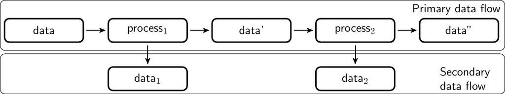

Figure 1: Primary and secondary data flows in an R script. The primary flow follows the execution of an R script, while in the background a secondary data flow (e.g. logging information) is created.

### 1.1 Prior art

There are several packages that generate a secondary data flow from a running script. One straightforward application concerns logging messages that report on the status of a running script. To create a logging message, users edit their code by inserting logging expressions where desired. Logging expressions are functions calls that help to build expressions, for example, by automatically adding a timestamp. Configuration options usually include a measure of logging verbosity and setting an output channel that controls where logging data will be sent. Changing these settings relies on communication from the main script to the functionality that controls the flow of logging data. In *logger* (Daróczi 2021), this is done by manipulating a variable stored in the package namespace using special helper functions. The *logging* package (Frasca 2019) also uses an environment within the namespace of the package to manage option settings, while *futile.logger* (Rowe 2016) implements a custom global option settings manager that is somewhat comparable to R’s own `options()` function.

Packages *bench* (Hester 2020a) and *microbenchmark* (Mersmann 2019) provide time profiling of single R expressions. The *bench* package also includes memory profiling. Their purpose is not to derive a secondary data flow from a running production script as in Figure 1 but to compare the performance of R expressions. Both packages export a function that accepts a sequence of expressions to profile. These functions take control of expression execution and insert time and/or memory measurements where necessary. Options, such as the number of times each expression is executed, are passed directly to the respective function.

Unit testing frameworks provide another source of secondary data flows. Here, an R script is used to prepare, set up, and compare test data, while the results of comparisons are tapped and reported. Testing frameworks are provided by *testthat* (Wickham 2011), *RUnit*, (Burger et al. 2018), *testit* (Xie 2021), *unitizer* (Gaslam 2021), and *tinytest* (van der Loo 2020). The first three packages (*testthat*, *RUnit*, and *testit*) all export assertion functions that generate condition signals to convey information about test results. Packages *RUnit* and *testit* use `sys.source()` to run a file containing unit test assertions and exit on the first error while *testthat* uses `eval()` to run expressions, capture conditions, and test results and reports afterward. The *unitizer* framework is different because it implements an interactive prompt to run tests and explore their results. Rather than providing explicit assertions, *unitizer* stores results of all expressions that return a visible result and compares their output at subsequent runs. Interestingly, *unitizer* allows for optional monitoring of the testing environment. This includes environment variables, options, and more. This is done by manipulating the code of (base) R functions that manage these settings and masking the original functions temporarily. These masking functions then provide parts of the secondary data flow (changes in the environment). Finally, *tinytest* is based on the approach that is the topic of this paper, and it will be discussed as an application below.

Finally, we note the *covr* package of Hester (2020b). This package is used to keep track of which expressions of an R package are run (covered) by package tests or examples. In this case, the primary data flow is a test script executing code (functions, methods) stored in another script, usually in the context of a package. The secondary flow consists of counts of how often each expression in the source is executed. The package works by parsing and altering the code in the source file, inserting expressions that increase appropriate counters. These counters are stored in a variable that is part of the package’s namespace.

Summarizing, we find that in logging packages, the secondary data flow is invoked explicitly by users while configuration settings are communicated by manipulating a global state that may or may not be directly accessible by the user. For benchmarking packages, the expressions are passed explicitly to an ‘expression runner’ that monitors the effect on memory and passage of time. In most test packages, the secondary flow is invoked explicitly using special assertions that throw condition signals. Test files are run using functionality that captures and administrates signals where necessary. Two of the discussed packages explicitly manipulate existing code before running it to create a secondary data flow. The *covr* package does this to update expression counters and the *unitizer* package to monitor changes in the global state.

### 1.2 Contribution of this paper

The purpose of this paper is to first provide some insight into the problem of managing multiple data flows, independent of specific applications. In the following section, we discuss managing a secondary data stream from the point of view of changing the way in which expressions are combined and executed by R.

Next, we highlight two programming patterns that allow one to derive a secondary data stream, both in non-interactive (while executing a file) and in interactive circumstances. The methods discussed here do not require explicit inspection or modification of the code that describes the primary data flow. It is also not necessary to invoke signaling conditions to transport information from or to the secondary data stream.

We also demonstrate a combination of techniques that allow users to parameterize the secondary flow without resorting to global variables, global options, or variables within a package’s namespace. We call this technique ‘local masking’ with ‘local side effects’. It is based on temporarily and locally masking a user-facing function with a function that does exactly the same except for a side effect that passes information to the secondary data flow.

As examples, we discuss two applications where these techniques have been implemented. The first is the *lumberjack* package (Loo 2021), which allows for tracking changes in R objects as they are manipulated expression by expression. The second is *tinytest* (van der Loo 2020), a compact and extensible unit testing framework.

Finally, we discuss some advantages and limitations to the techniques proposed.

## 2 Concepts

In this section we give a high-level overview of the problem of adding a second data flow to an existing one, and general way to think about a solution. The general approach was inspired by a discussion of Milewski (2018) and is related to what is sometimes called a *bind operator* in functional programming.

Consider as an example the following two expressions, labeled $e_1$ and $e_2$.

```r
  e1:  x <- 10
  e2:  y <- 2*x
```

We would like to implement some kind of monitoring as these expressions are evaluated. For this purpose, it is useful to think of $e_1$ and $e_2$ as functions that accept a set of key-value pairs, possibly alter the set’s contents, and return it. In R this set of key-value pairs is an `environment`, and usually, it is the global environment (the user’s workspace). Starting with an empty environment $\{\}$ we get:
$$\begin{aligned}
e_1(\{\}) &= \{(\texttt{"x"},\texttt{10})\}\\
e_2(e_1(\{\})) &= \{(\texttt{"x"}, \texttt{10}),(\texttt{"y"}, \texttt{20})\}
\end{aligned}$$
In this representation, we can write the result of executing the above script in terms of the function composition operator $\circ$:
$$\begin{aligned}
e_2(e_1(\{\})) = (e_2\circ e_1)(\{\}).
\end{aligned}$$
And in general, we can express the final state $\mathcal{U}$ of any environment after executing a sequence of expressions $e_1,e_2,\cdots,e_k$ as:
$$\label{eq:compose}
\begin{aligned}
\mathcal{U} = (e_k\circ e_{k-1}\circ \cdots\circ e_1)(\{\}),
\end{aligned} \tag{1}$$
where we assumed without loss of generality that we start with an empty environment. We will refer to the sequence $e_1\ldots e_k$ as the ‘primary expressions’ since they define a user’s main data flow.

We now wish to introduce some kind of logging. For example, we want to count the number of evaluated expressions, not counting the expressions that will perform the count. The naive way to do this is to introduce a new expression, say $n$:

```r
  n:   if (!exists("N")) N <- 1 else N <- N + 1
```

And we insert this into the original sequence of expressions. This amounts to the cumbersome solution:
$$\begin{aligned}
\mathcal{U}\cup\{(\texttt{"N"},k)\} = (n\circ e_k \circ n\circ e_{k-1}\circ n\circ \cdots n\circ e_{1})(\{\}),
\label{eq:insert}
\end{aligned} \tag{2}$$
where the number of executed expressions is stored in `N`. We shall refer to `n` as a ‘secondary expression’, as it does not contribute to the user’s primary data flow.

The above procedure can be simplified if we define a new function composition operator $\circ_n$ as follows:
$$\begin{aligned}
a\circ_n b = a\circ n \circ b.
\end{aligned}$$
One may verify the associativity property $a\circ_n(b\circ_n c)=(a\circ_n b)\circ_n c$ for expressions $a$, $b$, and $c$, so $\circ_n$ can, indeed, be interpreted as a new function composition operator. Using this operator we get
$$\begin{aligned}
\mathcal{U}\cup\{(\texttt{"N"},k-1)\} = (e_k\circ_n e_{k-1}\circ_n \cdots\circ_n e_1)(\{\}),
\label{eq:compose1}
\end{aligned} \tag{3}$$
which gives the same result as Equation (2) up to a constant.

If we are able to alter function composition, then this mechanism can be used to track all sorts of useful information during the execution of $e_1,\ldots, e_k$. For example, a simple profiler is set up by timing the expressions and adding the following expression to the function composition operator.

```r
  s: if (!exists("S")) S <- Sys.time() else S <- c(S, Sys.time())
```

After running $e_k\circ_s\cdots\circ_s e_1$, `diff(S)` gives the timings of individual statements. A simple memory profiler is defined as follows.

```r
  m: if (!exists("M")) M <- sum(memory.profile()) else M <- c(M, sum(memory.profile()))
```

After running $e_k\circ_m\cdots\circ_m e_1$, `M` gives the amount of memory used by R after each expression.

We can also track changes in data, but it requires that the composition operator knows the name of the R object that is being tracked. As an example, consider the following primary expressions.

```r
  e1:  x <- rnorm(10)
  e2:  x[x<0] <- 0
  e3:  print(x)
```

We can define the following expression for our modified function composition operator.

```r
  v:  {
        if (!exists("V")){
          V <- logical(0)
          x0 <- x
        }
        if (identical(x0,x)) V <- c(V, FALSE)
        else V <- c(V, TRUE)
        x0 <- x
      }
```

After running $e_3\circ_v e_2\circ_v e_1$, the variable `V` equals `c(TRUE, FALSE)`, indicating that $e_2$ changed `x`, and $e_3$ did not.

These examples demonstrate that redefining function composition yields a powerful method for extracting logging information with (almost) no intrusion on the user’s common workflow. The simple model shown here does have some obvious setbacks: first, the expressions inserted by the composition operator manipulate the same environment as the user expressions. The user- and secondary expressions can therefore interfere with each other’s results. Second, there is no direct control from the primary sequence over the secondary sequence: the user has no explicit control over starting, stopping, or parametrizing the secondary data stream. We demonstrate in the next section how these setbacks can be avoided by evaluating secondary expressions in a separate environment and by using techniques we call ‘local masking’ and ‘local side-effect’.